# COMM621 Text as data SP-2022

# Text analytics

## Text cleaning

**Why text cleaning?**

Textual data are always messy. The data may contain words that, if taken out of context, would be meaningless. You may also encounter a group of different words which convey the same meaning. Or you might have to convert slangs and acronyms into standard English, or emojis into something computer can recognize. Only by cleaning the mess and the noise in the text will you be able to discern useful patterns and signals.

*From corpus to DFM* There is a lot of interest in quantifying and visualizing textual data. Texts reveal [our thoughts](https://blogs.wsj.com/numbers/mining-tweets-for-public-opinion-1118/), [our personality](https://wordwatchers.wordpress.com/), and [the pulse of a society](http://theconversation.com/how-twitter-gives-scientists-a-window-into-human-happiness-and-health-62255). We broadly refer to the *quantification of text* as *text mining*. Thanks to the developments in [Natural Language Processing](https://en.wikipedia.org/wiki/Natural_language_processing) and [Information retrieval](https://en.wikipedia.org/wiki/Information_retrieval), we now have a wide selection of easy-to-use R libraries for cleaning, transforming, quantifying, and visualizing text.

**Which R library?**

Throughout the tutorials on text mining, we will use the library *quantaeda*, which stands for Quantitative Analysis of Textual Data. You can visit the [library website](https://quanteda.io/) to view many examples. There is another decent text mining library called *tidytext*. Although we will not use it since there is a considerable overlap in functionality between the two libraries, I still highly recommend checking out [tidytext](https://cran.r-project.org/web/packages/tidytext/vignettes/tidytext.html) and [a free e-book](https://www.tidytextmining.com/) written by the library author.

**What data?** In this tutorial, we will experiment with a dataset containing 4,995 tweets containing the #metoo hashtag. You can download the data [here](https://curiositybits.cc/files/metoo.csv). Or you can run the code below to download the data into your RStudio. For faster loading, we ask R to show the first 50 tweets and four selected columns. Text analytics typically begins with text files (e.g., a data frame or a CSV file) containing character strings (the actual text) and the metadata of the text. In the example below, we are interested in analyzing the text content in the *text* column.

```r
library(readr)
library(DT)

metoo_tweets <- read.csv("https://curiositybits.cc/files/metoo.csv")

#show the first 500 arrests
datatable(metoo_tweets[1:50,c("status_id","screen_name","text","retweet_count")], options = list(pageLength = 5))
```

|  | status_id | screen_name | text | retweet_count |
| --- | --- | --- | --- | --- |
| 1 | x1103092683717906432 | KCom416 | #METOO Confrontation can be alarming for many, yet after reading the article by Jessi Hempel it makes me wonder why are we afraid that if we speak out it will hurt who harmed us? Do not put down those… | 0 |
| 2 | x1103090889126264833 | KCom416 | Jessi Hempel's The Problem with #METOO and Viral Outrage represent the key elements of a major issue in society; sexual harassment and women are finally speaking out about their past tragedies. #COM41… | 0 |
| 3 | x1103092651140808705 | thegirlconlasod | From and today and yesterday. Are you really the relationship app? Or only the relationship app for thin white people? #hinge @hinge #MeToo #harassment #relationshipapp https://t.co/c2KZ1UQjc4 | 0 |
| 4 | x1103092268490280961 | thegirlconlasod | From and today and yesterday. Are you really the relationship app? Or only the relationship app for thin white people? #hinge @hinge #MeToo #harassment #relationshipapp https://t.co/kX3rV0AdAu | 0 |
| 5 | x1103092648888410112 | wilsongrout | He looks like he's having a break down in the interview 😂 KARMA BITCH #RKelly #TimesUp #MeToo #MuteRKelly | 0 |
| 6 | x1103092554919280640 | mindyonfire | #MeToo #FairGame #WeSeeYou #FindShellyMiscavige #ScientologyMustStop #JusticefortheAbused https://t.co/nN6oTBYoUT | 0 |
| 7 | x1103092535214235648 | JDSupra | [Webinar] Mandatory Sexual Harassment Training in the #MeToo Era: Will Your State Require It? - March 6th, 1:00pm ET - Register now https://t.co/5B0QPwK9d4 | 0 |
| 8 | x1103092514561486848 | SiriAgrell | “Strong women who uphold the Constitution seem to be quite popular right now,” says @gillianhnatiw as she explains @LEAFNational mandate before introducing #metoo founder @TaranaBurke https://t.co/ebc… | 0 |
| 9 | x1103092487072239616 | sweetparadox79 | Hello twatter land lol #metoo #MentalHealthMatters #AKF #SPNFamily | 0 |
| 10 | x1102746820051193857 | sweetparadox79 | Seriously guys?#MeToo not a clue enough that I'm not interested??? | 0 |

[output cut: 40 more lines]

**Workflow**

A typical workflow in text analytics is:

1. **create a corpus from text files**;
2. **tokenization**;
3. **create a DFM (document-feature matrix)**;
4. **conduct a variety of text analyses**.

**Corpus**

Think of a *corpus* as a container of different *documents*. A *corpus* is the complete collection of text you want to analyze, *Documents* are individual units in that collection. For example, if you want to analyze someone’s tweets (the corpus), each unique tweet can be treated as a document. Another example is: if you want to compare tweets sent by GOP and the Democratic Party, you can treat all tweets sent by one party as a single document. This treatment will lead you to have two documents in the corpus. Below we will create a corpus of 4,995 documents (i.e., tweets).

```r
library(quanteda)
library(quanteda.textstats)
library(quanteda.textplots)

metoo_tweets$text <- as.character(metoo_tweets$text) #optional step: convert the text column to characters

tweet_corpus <- corpus(metoo_tweets,docid_field = "status_id",text_field = "text")

tweet_corpus
```

```
## Corpus consisting of 4,995 documents and 86 docvars.
## x1103092683717906432 :
## "#METOO Confrontation can be alarming for many, yet after rea..."
##
## x1103090889126264833 :
## "Jessi Hempel's The Problem with #METOO and Viral Outrage rep..."
##
## x1103092651140808705 :
## "From and today and yesterday. Are you really the relationshi..."
##
## x1103092268490280961 :
## "From and today and yesterday. Are you really the relationshi..."
##
## x1103092648888410112 :
## "He looks like he's having a break down in the interview 😂 KA..."
##
## x1103092554919280640 :
## "#MeToo #FairGame #WeSeeYou #FindShellyMiscavige #Scientology..."
##
## [ reached max_ndoc ... 4,989 more documents ]
```

Alternatively, you can combine tweets sent by the same users and create a corpus in which a document is an user’s tweets.You will see that the corpus created from the code below contains 4,090 documents (i.e., unique users). In order to create the corpus, we first create a new data frame (called tweets_byusers) by using aggregate() to merge tweets from the same user. Then, in corpus(), we specify *docid_field = “screen_name”*. This tells R to recognize the city column as the document IDs.

```r
library(dplyr)
tweets_byusers <- aggregate(text~screen_name, data = metoo_tweets, paste0, collapse=". ")

#create a corpus based on the new data frame
user_corpus <- corpus(tweets_byusers,docid_field = "screen_name",text_field = "text")

user_corpus
```

```
## Corpus consisting of 4,090 documents.
## _abbie_brown :
## "the girl who seemed unbreakable, broke. she dropped the fake..."
##
## _AntiPiedPiper :
## "@akbaspinar Het aantal moorden in België ligt op 900 per jaa..."
##
## _Dionysos_ :
## "Als je filmsterren opknoopt aan de hoogste boom omdat ze vro..."
##
## _EML__ :
## "So during the #MeToo #TimesUp era, is twitter dismissing the..."
##
## _FoggyDew :
## "@DavidKlion @VicBergerIV @AOC @JerryFalwellJr @CPAC An, insu..."
##
## _HollyC__ :
## "Someone needs to get her actual help. A 5150 .. something. I..."
##
## [ reached max_ndoc ... 4,084 more documents ]
```

## Tokenization

Run the code below and see how text is tokenized.

This tokenize the second tweet based on words.

```r
tokens(tweet_corpus[2])
```

```
## Tokens consisting of 1 document and 86 docvars.
## x1103090889126264833 :
##  [1] "Jessi"     "Hempel's"  "The"       "Problem"   "with"      "#METOO"
##  [7] "and"       "Viral"     "Outrage"   "represent" "the"       "key"
## [ ... and 23 more ]
```

**tokens(), by default, segments a corpus into tokens where each token represents a word**. The code above tokenizes the second document (i.e., the 2nd tweet) in the corpus.

We commonly tokenize corpus based on words. The following code tokenizes the corpus based on sentences so that each unique sentence is treated as a token. We do that by adding *what = “sentence* to the *tokens()* function.

```r
tokens(tweet_corpus[2], what = "sentence")
```

```
## Tokens consisting of 1 document and 86 docvars.
## x1103090889126264833 :
## [1] "Jessi Hempel's The Problem with #METOO and Viral Outrage represent the key elements of a major issue in society; sexual harassment and women are finally speaking out about their past tragedies."
## [2] "#COM416 https://t.co/15Uv2nGGGo"
```

## DFM

With a corpus, we can go ahead and create a DFM (document feature matrix). What is a DFM? The best way to understand it is perhaps by playing around one. Run the code below. It will construct a DFM based on the corpus of 4,995 documents.

DFM is a matrix. Numbers in DFM represent how many times a token (commonly referring to a word or a sentence) appears in a given document. In the output above. The word *confrontation* appears once in document *x1103092683717906432* (this refers to the status_id of a tweet).

Please note that the dfm() function performs tokenization under the hood. In other words, by default, dfm() tokenizes your text first before constructing a DFM object.

```r
tweets_dfm <- dfm(tweet_corpus)

tweets_dfm[1:5,1:5] #show the first 5 words in the first 5 documents
```

```
## Document-feature matrix of: 5 documents, 5 features (64.00% sparse) and 86 docvars.
##                       features
## docs                   #metoo confrontation can be alarming
##   x1103092683717906432      1             1   1  1        1
##   x1103090889126264833      1             0   0  0        0
##   x1103092651140808705      1             0   0  0        0
##   x1103092268490280961      1             0   0  0        0
##   x1103092648888410112      1             0   0  0        0
```

*tweets_dfm[1:5,1:5]* gives you the frequency distribution of the first 5 words across the first 5 documents. The complete matrix (the object named reviews_dfm) is 25,974 by 4,995. It means that this dfm object has 25,974 features (i.e., words) across 4,995 documents (tweets).

After you have a DFM from your text data, you can do all sorts of things. For instance, run the code below will show you the most frequent terms in your corpus.

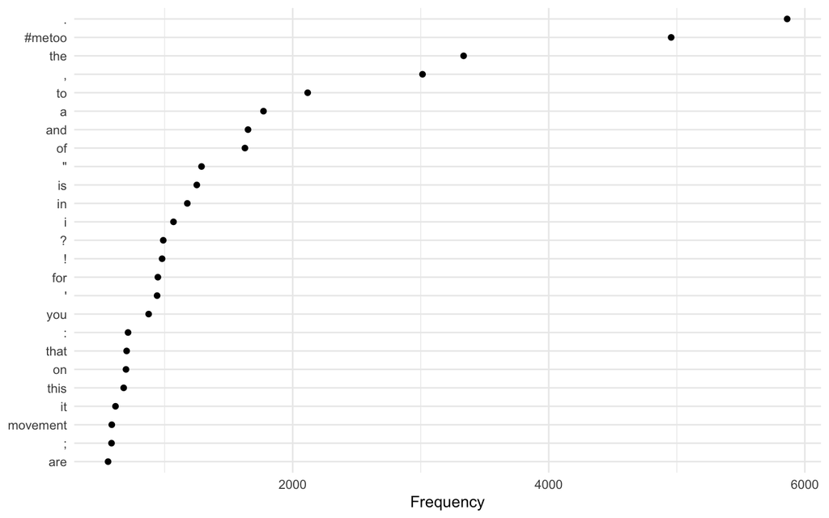

```r
library(ggplot2)

tweets_dfm %>%
  textstat_frequency(n = 25) %>%
  ggplot(aes(x = reorder(feature, frequency), y = frequency)) +
  geom_point() +
  coord_flip() +
  labs(x = NULL, y = "Frequency") +
  theme_minimal()
```

## Filter unwanted words

In the code below, a number of cleaning criteria are added. Observe changes in the output.

```r
tokens(tweet_corpus[2],remove_punct = TRUE,remove_numbers = TRUE, remove_symbols = TRUE, remove_twitter=TRUE, remove_url=TRUE)
```

```
## Tokens consisting of 1 document and 86 docvars.
## x1103090889126264833 :
##  [1] "Jessi"     "Hempel's"  "The"       "Problem"   "with"      "#METOO"
##  [7] "and"       "Viral"     "Outrage"   "represent" "the"       "key"
## [ ... and 20 more ]
```

Now, let’s apply tokens() to tokenize the whole corpus and identify the most frequent terms. The tokenization produces an object call *tok*. We can create a DFM from review_tok.

```r
tok <- tokens(tweet_corpus,remove_punct = TRUE,remove_numbers = TRUE, remove_symbols = TRUE, remove_twitter=TRUE, remove_url=TRUE)

tweets_dfm <- dfm(tok)

#find 20 most frequent terms
topfeatures(tweets_dfm, 20)
```

```
##   #metoo      the       to        a      and       of       is       in
##     4956     3335     2117     1772     1651     1627     1251     1177
##        i      for      you     that       on     this       it movement
##     1069      947      875      703      698      680      616      587
##      are     with    women      amp
##      558      519      464      447
```

Hold on, the most frequent terms are: *the*, *to*, *a*, *and*, *of*, *is*? This tells us hardly anything interesting about the data. Well, this is because there are common stop words in our data. [Stop words](https://en.wikipedia.org/wiki/Stop_words) are commonly used function words that we ask algorithms to ignore in processing text data. In many text analytics tasks, we reckon such stop words as meaningless noises. But, there is a school of thoughts that argue how people use function words (e.g., *the*, *is*, *at*, *which*, and *on*) reveals important insights about social identities, power dynamics in a communication context, and personality. [Read more here](https://www.npr.org/sections/health-shots/2012/04/30/151550273/to-predict-dating-success-the-secrets-in-the-pronouns).

To remove stop words from tok (the tokenized corpus created from the previous step), use the code below.

```r
tok <- tokens_select(tok, pattern = stopwords('en'), selection = 'remove')
```

Alternatively, you can directly use *remove = stopwords(“english”)* inside the *dfm()* function. It will do the same trick.

```r
tweets_dfm <- dfm(tweet_corpus, remove = stopwords("english"), stem = FALSE, remove_punct = TRUE)
```

Run the below code blocks. Each will test a new set of cleaning criteria.

```r
tok <- tokens_select(tok, min_nchar=3, selection = 'keep') #remove any word shorter than3 characters.

tok <- tokens_select(tok, pattern = c("metoo","twitter","however"), selection = 'remove') #remove additional filter words.
```

Ever wonder what *stem = FALSE* means in the code above? Or do you want to try other cleaning criteria? *Stemming* refers to a cleaning process that chops off the ends of words. Why do we do that? This is because different words (e.g., *working*, *works*, and *worked*) may share a same stem/root word and thus convey similar meaning. In text mining, we might want to treat such words as identical.

With the cleaned DFM, you can visualize 25 most frequent terms.

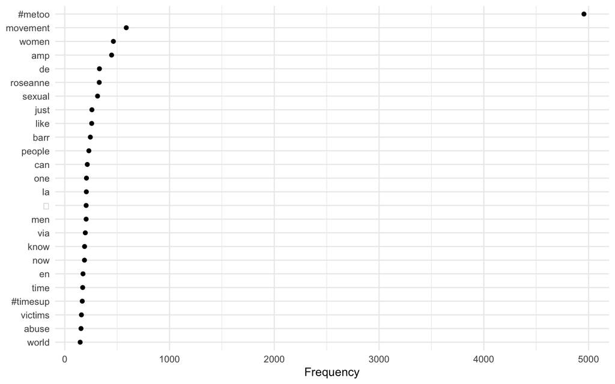

```r
tweet_corpus <- corpus(metoo_tweets,docid_field = "status_id",text_field = "text")

tok <- tokens(tweet_corpus,remove_punct = TRUE,remove_numbers = TRUE, remove_symbols = TRUE, remove_twitter=TRUE, remove_url=TRUE)

tweets_dfm <- dfm(tok,remove = stopwords("english"))

tweets_dfm %>%
  textstat_frequency(n = 25) %>%
  ggplot(aes(x = reorder(feature, frequency), y = frequency)) +
  geom_point() +
  coord_flip() +
  labs(x = NULL, y = "Frequency") +
  theme_minimal()
```

## Word cloud

We can create a word cloud using the most frequent terms in the tweets.

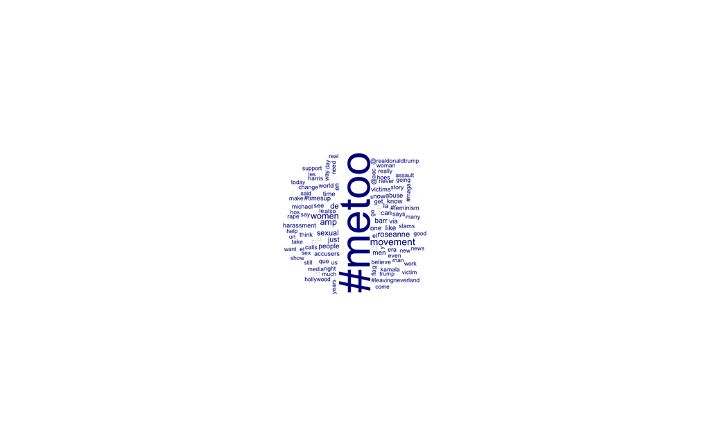

```r
textplot_wordcloud(tweets_dfm, max_words = 100)
```

## Keyness

Just because a term is frequent, does not mean it is a “keyword.” In text mining, keywords are measured by [“keyness”](http://www.thegrammarlab.com/?p=193). It shows how *distinctive* a word is for a group of texts when compared to the texts in other groups. For instance, we suspect that verified Twitter users and unverified users tweet about #metoo differently. We can use the *textstat_keyness* function to find terms that distinguish verified users’ tweets from the tweets from unverified users.

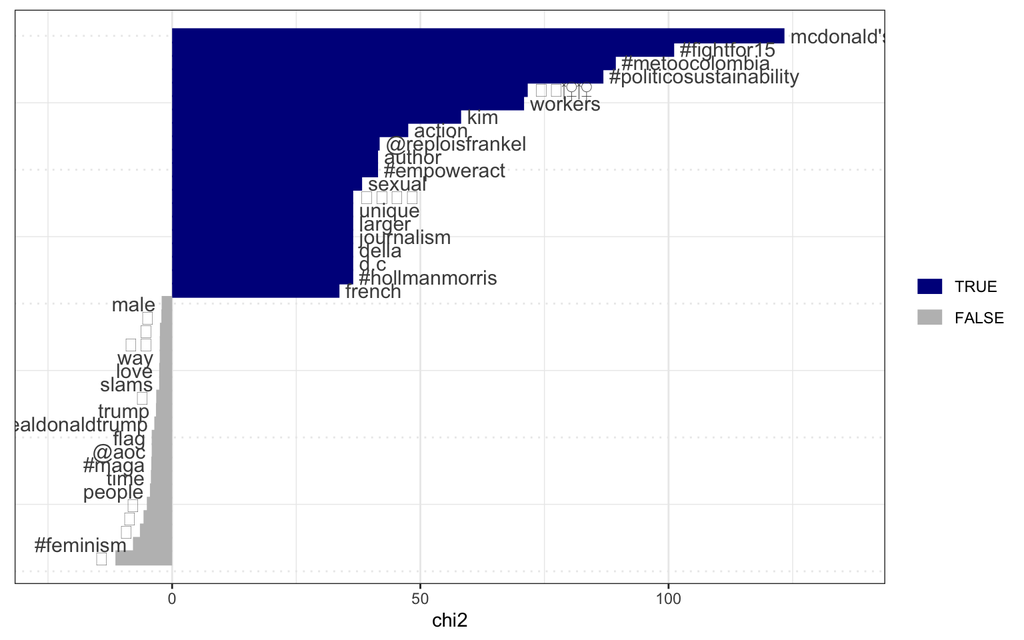

```r
tok <- tokens(tweet_corpus,remove_punct = TRUE,remove_numbers = TRUE, remove_symbols = TRUE, remove_twitter=TRUE, remove_url=TRUE) %>%
    tokens_group(groups = verified)

tweets_dfm <- dfm(tok,remove = stopwords("english"))

result_keyness <- textstat_keyness(tweets_dfm, target = "TRUE")

# Plot estimated word keyness
textplot_keyness(result_keyness)
```

## N-gram

Text mining is a process of data reduction. It simplifies a complex text into tokens. Along the way, lots of information is lost, especially, when you take single words out of context. Next, we will try [N-grams](https://en.wikipedia.org/wiki/N-gram). N-grams can preserve multi-word phrases and expressions.

Below we construct bigrams and compare frequent bigrams between two groups of tweets: those sent by verified users and the ones sent by unverified users.

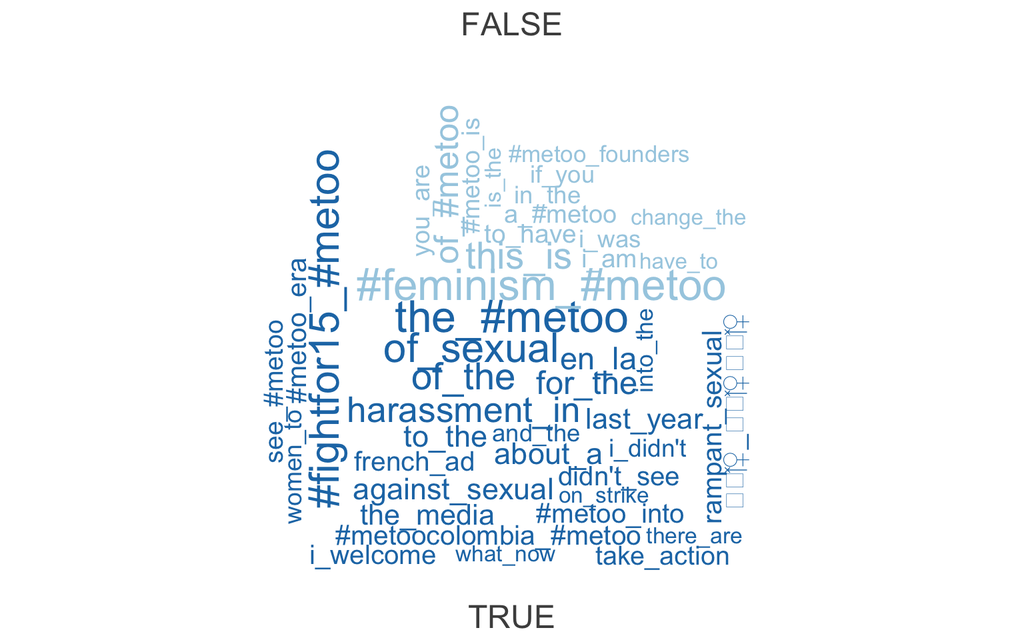

```r
tweet_corpus <- corpus(metoo_tweets,docid_field = "status_id",text_field = "text")

tok <- tokens(tweet_corpus,remove_punct = TRUE,remove_numbers = TRUE, remove_symbols = TRUE, remove_twitter=TRUE, remove_url=TRUE)

tok <- tokens_ngrams(tok, n = 2) %>%
    tokens_group(groups = verified)

tweets_dfm <- dfm(tok)

set.seed(132)
textplot_wordcloud(tweets_dfm, comparison = TRUE, max_words = 100)
```

## Dictionary-based text analysis

**sentiment detection**

Researchers commonly use pre-defined and pre-tested dictionaries to identify themes and features in texts. The dictionary-based approach has been widely used in sentiment detection.During the 2012 US presidential election, Twitter, in partnership with several polling agencies, launched something called [Twitter Political Index](https://www.socialmediatoday.com/content/twitter-political-index). The idea was to track candidates’ popularity among voters based on sentiment expressed in tweets. Back then, such idea was a novelty. Nowadays, sentiment analysis of social media text has been widely applied in [marketing/PR](https://ipullrank.com/step-step-twitter-sentiment-analysis-visualizing-united-airlines-pr-crisis/), [electoral forecasting](https://techcrunch.com/2016/11/10/social-media-did-a-better-job-at-predicting-trumps-win-than-the-polls/), and sports analytics. The NPR show Planet Money even built a [Twitter bot](https://twitter.com/botus?lang=en) to automatically trade stocks based on sentiments in Trump’s tweets.

Below we use a library called *syuzhet* to identify sentiments expressed in tweets. The library uses the [NRC Emotion Lexicon](http://sentiment.nrc.ca/lexicons-for-research/) which rates words by eight dimensions: *joy*, *anger*, *anticipation*, *disgust*, *fear*, *sadness*, *surprise* and *trust*.

```r
library(syuzhet) #this is the library for sentiment detection

#extract sentiments
Sentiment <- get_nrc_sentiment(metoo_tweets$text)

alltweets_senti <- cbind(metoo_tweets, Sentiment)
```

Next, we sum up across sentiment types and plot the data.

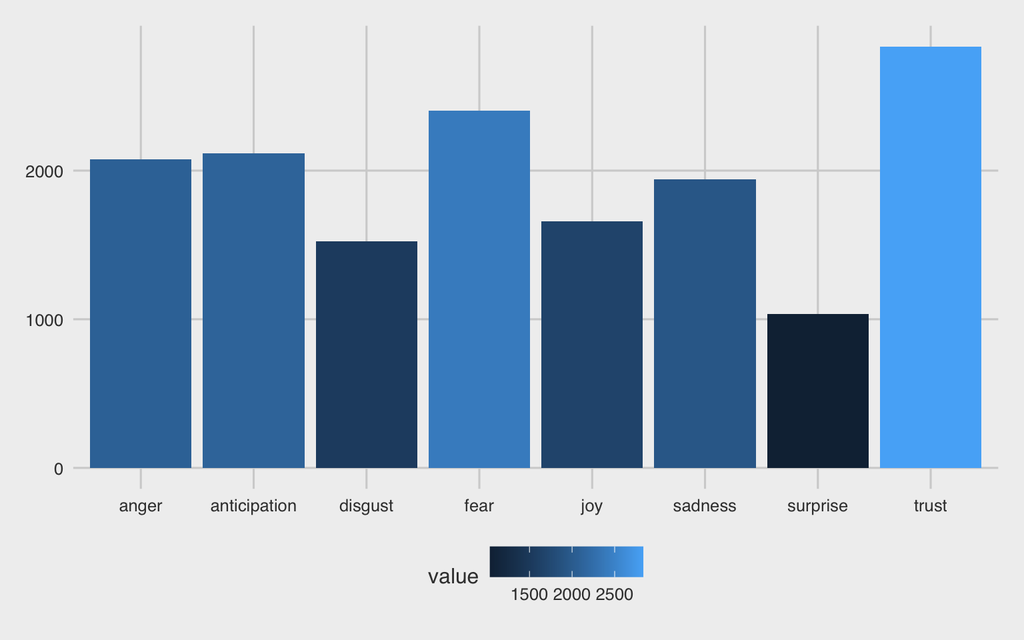

```r
library(ggplot2)
library(ggthemes)
library(reshape2)
library(dplyr)

senti_aggregated <- Sentiment %>%
  summarise(anger = sum(anger),
            anticipation = sum(anticipation),
            disgust = sum(disgust),
            fear = sum(fear),
            joy = sum(joy),
            sadness = sum(sadness),
            surprise = sum(surprise),
            trust = sum(trust)) %>% melt

ggplot(data = senti_aggregated, aes(x = variable, y = value)) +
  geom_bar(aes(fill = value), stat = "identity") + geom_smooth(method = "lm", se = FALSE) + scale_color_fivethirtyeight("cyl") +
  theme_fivethirtyeight()
```

## Text networks

To understand what a semantic network looks like, go ahead and run the code below.

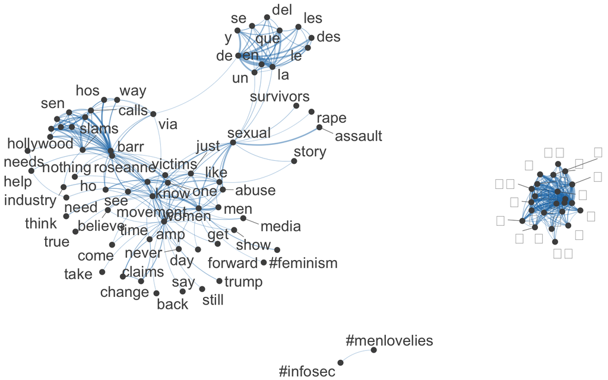

```r
library(quanteda)
library(ggplot2)

tweet_corpus <- corpus(metoo_tweets,docid_field = "status_id",text_field = "text")

tok <- tokens(tweet_corpus,remove_punct = TRUE,remove_numbers = TRUE, remove_symbols = TRUE, remove_twitter=TRUE, remove_url=TRUE)

tweets_dfm <- dfm(tok, remove = stopwords("english"))

#create a feature co-occurrence matrix (FCM)
tweets_fcm <- fcm(tweets_dfm)

#extract the top 50 frequent terms from the FCM object
feat <- names(topfeatures(tweets_fcm, 100))

#trim the old FCM object into a one that contains only the 50 frequent terms
fcm_select <- fcm_select(tweets_fcm, pattern = feat)

set.seed(144)
textplot_network(fcm_select, min_freq = 0.8)
```

What you see in the output are a bunch of words interconnected to each other. A semantic network can tell us the most central concept/ideas in your corpus. We can use mathematical functions to quantify each position in a semantic network. For example, centrally located words tend to have higher [*betweenness centrality*](https://en.wikipedia.org/wiki/Betweenness_centrality). Even without any mathematic calculation, we can easily spot the most central words based on the visualization. The concept of semantic networks is developed from the [graph theory](https://en.wikipedia.org/wiki/Graph_theory) and [social network analysis](https://en.wikipedia.org/wiki/Social_network_analysis). We will have a separate set of tutorials on online social networks.

**How are words connected to one and another?** You may wonder about that. In quantaeda, a semantic network is referred to as feature co-occurrence matrix (FCM). It is a type of network based on co-occurrence: more specifically, two words are linked to each other if they appear in the same document. In our case, two words are connected to each other if they occur in the same review.

The semantic network approach can be useful in mapping out central ideas and see how different ideas are connected and clustered. A shortcoming here, though, is that there are too many vague words in the corpus. A refined approach is tagging each word token as noun, adjective, or verb (a process called [Part-of-speech tagging](https://www.bing.com/search?q=pos+tagging&PC=U316&FORM=CHROMN)) and then create a semantic network based only on one type of words, say, a semantic network entirely based on nouns or adjectives. You may also consider this approach in analyzing Twitter hashtags. You will learn alot by looking at how different hashtags are concentrated and clustered based on their co-occurrence in the same tweet. See the code below.

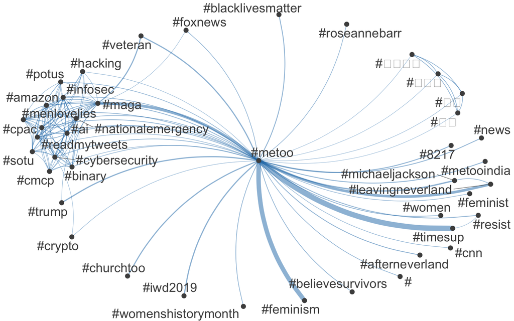

```r
tweet_corpus <- corpus(metoo_tweets,docid_field = "status_id",text_field = "text")

tweets_dfm <- dfm(tweet_corpus)

tweets_dfm <- dfm_select(tweets_dfm, pattern = ("#*"))

tweets_fcm <- fcm(tweets_dfm)

#extract the top 50 frequent terms from the FCM object
feat <- names(topfeatures(tweets_fcm, 100))

#trim the old FCM object into a one that contains only the 50 frequent terms
fcm_select <- fcm_select(tweets_fcm, pattern = feat)

set.seed(144)
textplot_network(fcm_select, min_freq = 0.8)
```

## Topic models

**What is a topic model?**

Have you dreamed of a day when algorithms can quickly scan through your textbooks and give you a bullet point summary? How convenient! No more tedious reading! Actually, there are algorithms out there that do automatic summarization of large-scale corpus. They are called *topic models*. In building topic models, we basically ask computers to discover some abstract topics from the text. The internal logic is this: words about the same topic tend to be used together in the same or adjacent semantic space.

**New library?**

The topic model feature is built in the quantaeda library. But you may need to install_topicmodels_.

**The workflow**

**But, what does *k=10* mean?**

By setting k=10, we ask the LDA algorithm to identify ten topics in the corpus. This is where things get extremely complicated and confusing. The algorithm is agnostic about how many topics are there in the corpus. So you will start with a k value and check if the keywords returned shows any clear distinction of topics. If you struggle to summarize the text based on the keywords returned, chances are it is not a good model. Then you will go back and adjust the k value until you find one that gives you somewhat sensible output.

If you want to plot key words from each topic model, try the following code in the library *tidytext*.

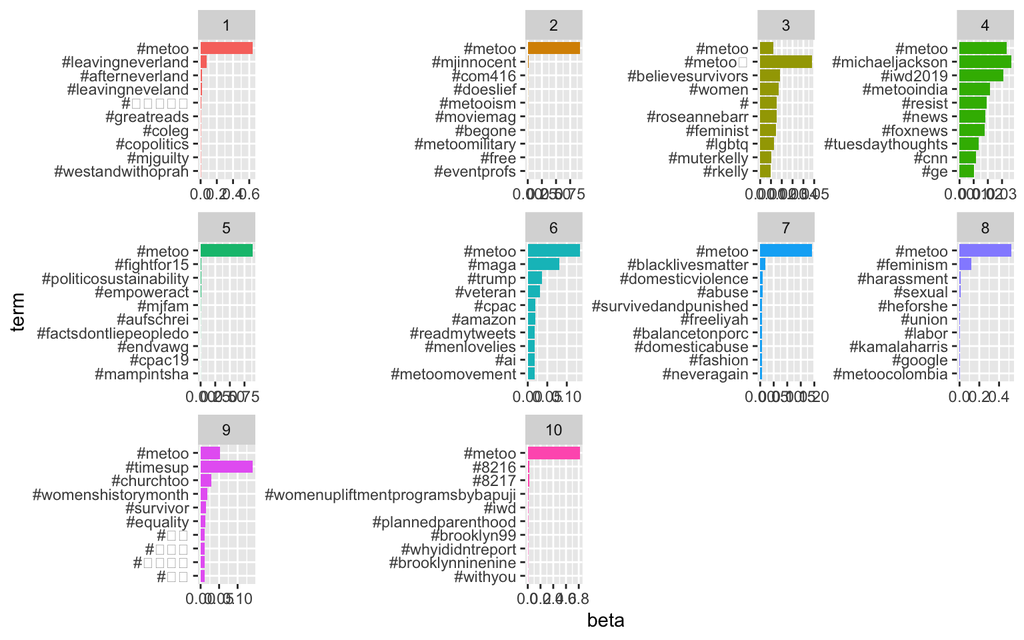

```r
library(tidytext)
library(topicmodels)

dfm_fortm <- convert(tweets_dfm, to = "topicmodels")
lda <- LDA(dfm_fortm, k = 10)

tuber_topics <- tidy(lda, matrix = "beta")

top_terms <- tuber_topics %>%
  group_by(topic) %>%
  top_n(10, beta) %>%
  ungroup() %>%
  arrange(topic, -beta)

top_terms %>%
  mutate(term = reorder(term, beta)) %>%
  ggplot(aes(term, beta, fill = factor(topic))) +
  geom_col(show.legend = FALSE) +
  facet_wrap(~ topic, scales = "free") +
  coord_flip()
```

**Extracting meaning?**

Based on your experience with topic models so far, do you think computers can extract true meanings from textual data?